# EDA Visualization with Matplotlib and Seaborn

```python
import matplotlib.pyplot as plt
import seaborn as sns
%matplotlib inline
import warnings
warnings.filterwarnings('ignore')
#magic command informs jupyter that you want your grap to show as output below the cells not as pop up
```

using line charts; it displays information as a seres of data points or makers, connected by straight lines. country-- Kanto years 6yrs intons per hectare

```python
yield_apples = [0.895, 0.91, 0.919, 0.926, 0.929, 0.931]
```

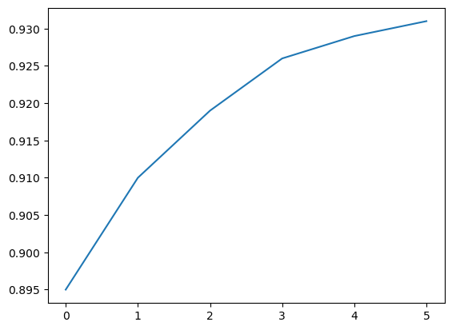

```python
plt.plot(yield_apples);
```

```python
#Customizing it to look better
```

```python
years = [2010, 2011, 2012, 2013, 2014, 2015]
yield_apples = [0.895, 0.91, 0.919, 0.926, 0.929, 0.931]
```

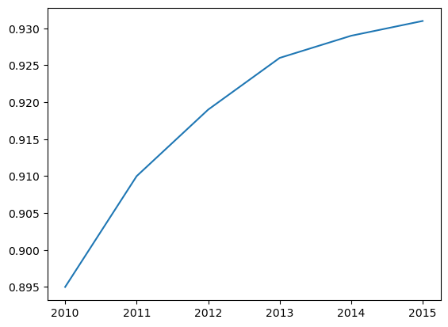

```python
plt.plot(years, yield_apples);
```

```python
#Axis Labes
```

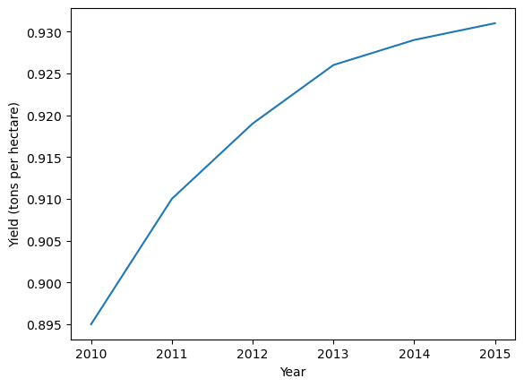

```python
plt.plot(years, yield_apples)
plt.xlabel('Year')
plt.ylabel('Yield (tons per hectare)');
```

### Plotting multiple lines in the same graph

```python
years = range(2000, 2012)
apples = [0.895, 0.91, 0.919, 0.926, 0.929, 0.931, 0.934, 0.936, 0.937, 0.940, 0.945, 0.947]
oranges = [0.962, 0.941, 0.930, 0.923, 0.918, 0.908, 0.907, 0.904, 0.909, 0.910, 0.913, 0.918]
```

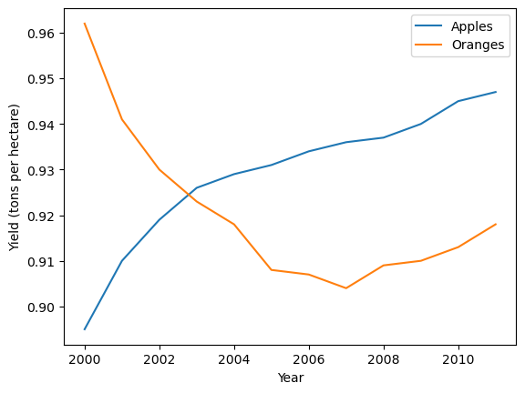

```python
plt.plot(years, apples)
plt.plot(years, oranges)
plt.xlabel('Year')
plt.ylabel('Yield (tons per hectare)')
plt.legend(['Apples', 'Oranges'])
plt.show()
```

### Chart Title and Legend

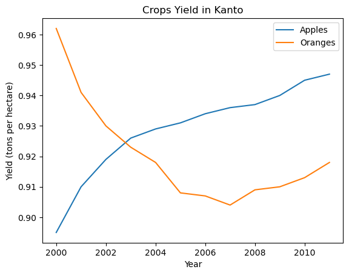

```python
plt.plot(years, apples)
plt.plot(years, oranges)

plt.xlabel('Year')
plt.ylabel('Yield (tons per hectare)')

plt.title('Crops Yield in Kanto')
plt.legend(['Apples', 'Oranges']);
```

### Line Markers

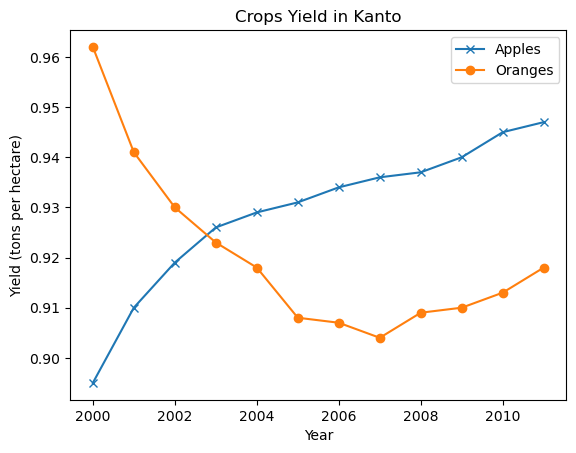

```python
plt.plot(years, apples, marker = 'x')
plt.plot(years, oranges, marker = 'o')

plt.xlabel('Year')
plt.ylabel('Yield (tons per hectare)')

plt.title('Crops Yield in Kanto')
plt.legend(['Apples', 'Oranges']);
```

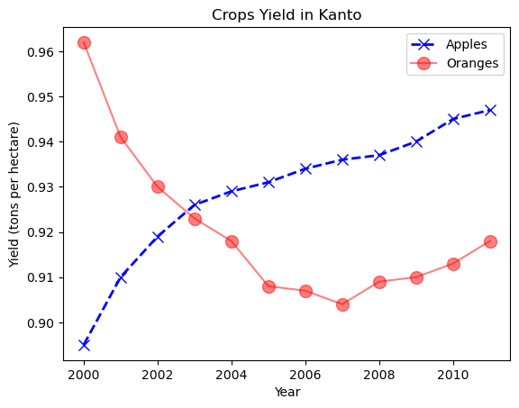

```python
plt.plot(years, apples, marker = 'x', c = 'blue', ls = '--', lw = 2,  ms = 8)
plt.plot(years, oranges, marker = 'o', c = 'red', ms = 10, alpha = .5 )

plt.xlabel('Year')
plt.ylabel('Yield (tons per hectare)')

plt.title('Crops Yield in Kanto')
plt.legend(['Apples', 'Oranges']);
```

## Changing the Figure Size

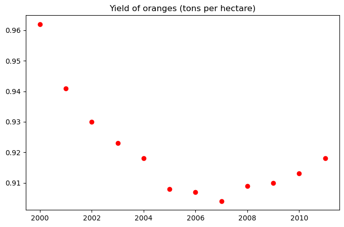

```python
plt.figure(figsize = (8, 5))

plt.plot(years, oranges, 'or')
plt.title('Yield of oranges (tons per hectare)')
```

fmt arguement provides a shortcut for specifying the line style, marker and line color. It can be provided as the third agruement to plt.plot fmt = 'o-r' fmt = 'o--b'

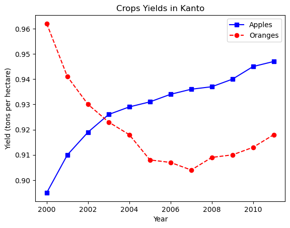

```python
plt.plot(years, apples, 's-b')
plt.plot(years, oranges, 'o--r')

plt.xlabel('Year')
plt.ylabel('Yield (tons per hectare)')

plt.title('Crops Yields in Kanto')
plt.legend(['Apples', 'Oranges']);
```

```python
remove the '--' in the fmt styling to have only markers and no line
```

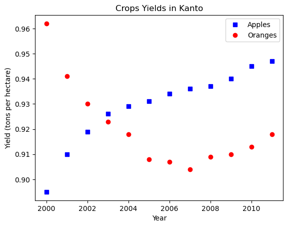

```python
plt.plot(years, apples, 'sb')
plt.plot(years, oranges, 'or')

plt.xlabel('Year')
plt.ylabel('Yield (tons per hectare)')

plt.title('Crops Yields in Kanto')
plt.legend(['Apples', 'Oranges']);
```

#### changing the figure size

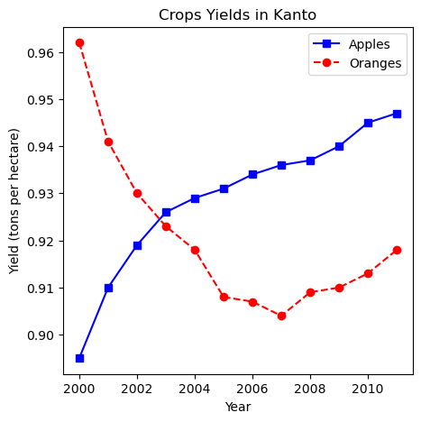

```python
plt.figure(figsize=(5, 5))
plt.plot(years, apples, 's-b')
plt.plot(years, oranges, 'o--r')

plt.xlabel('Year')
plt.ylabel('Yield (tons per hectare)')

plt.title('Crops Yields in Kanto')
plt.legend(['Apples', 'Oranges']);
```

## Improving Default Styles Using Seaborn

```python
sns.set_style('whitegrid')  #it gives a grid to your chat.
```

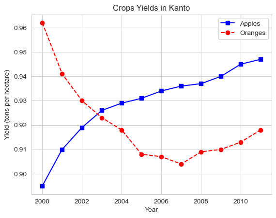

```python
plt.plot(years, apples, 's-b')
plt.plot(years, oranges, 'o--r')

plt.xlabel('Year')
plt.ylabel('Yield (tons per hectare)')

plt.title('Crops Yields in Kanto')
plt.legend(['Apples', 'Oranges']);
```

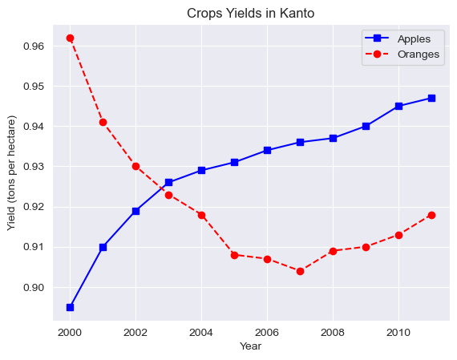

```python
sns.set_style('darkgrid')     #using a darkgrid background

plt.plot(years, apples, 's-b')
plt.plot(years, oranges, 'o--r')

plt.xlabel('Year')
plt.ylabel('Yield (tons per hectare)')

plt.title('Crops Yields in Kanto')
plt.legend(['Apples', 'Oranges']);
```

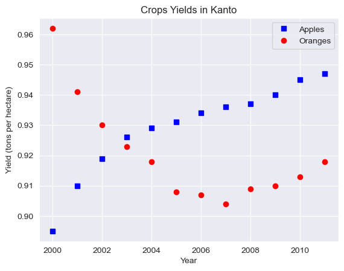

```python
plt.plot(years, apples, 'sb')
plt.plot(years, oranges, 'or')

plt.xlabel('Year')
plt.ylabel('Yield (tons per hectare)')

plt.title('Crops Yields in Kanto')
plt.legend(['Apples', 'Oranges']);
```

### Editing default styles

Editing the default styles directly by modifying the matplotlip rcparams dictionary. ie

matplotlib.rcParams

```python
import matplotlib
```

```python
matplotlib.rcParams   #matplotlib dictionary
```

[output not shown]

[output cut: 297 more lines]

[output not shown]

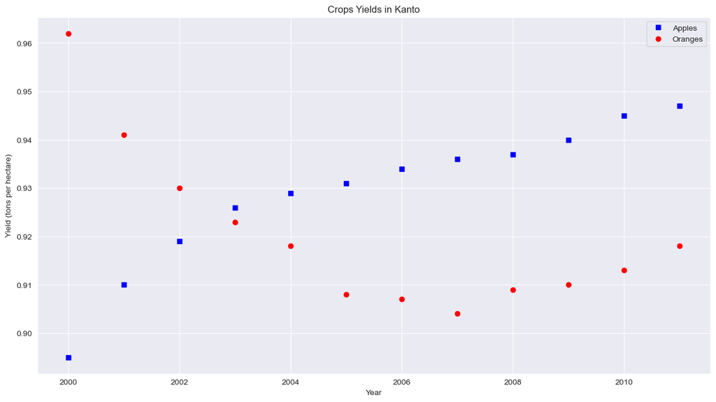

```python
matplotlib.rcParams['font.size']= 10.0
matplotlib.rcParams['font.family'] = 'sans-serif'
matplotlib.rcParams['figure.figsize'] = (15, 8)
matplotlib.rcParams['figure.facecolor'] = '#00000000'

plt.plot(years, apples, 'sb')
plt.plot(years, oranges, 'or')

plt.xlabel('Year')
plt.ylabel('Yield (tons per hectare)')

plt.title('Crops Yields in Kanto')
plt.legend(['Apples', 'Oranges']);
```

### Scatter Plot

Used to visualize the relationship between two variable as points on a two dimensional grid.

```python
import pandas as pd
```

```python
flowers = pd.read_csv('flowers.csv')
flowers
```

|  | sepal length | sepal width | petal length | petal width | species |
| --- | --- | --- | --- | --- | --- |
| 0 | 5.1 | 3.5 | 1.4 | 0.2 | setosa |
| 1 | 4.9 | 3.0 | 1.4 | 0.2 | setosa |
| 2 | 4.7 | 3.2 | 1.3 | 0.2 | setosa |
| 3 | 4.6 | 3.1 | 1.5 | 0.2 | setosa |
| 4 | 5.0 | 3.6 | 1.4 | 0.2 | setosa |
| ... | ... | ... | ... | ... | ... |
| 145 | 6.7 | 3.0 | 5.2 | 2.3 | virginica |
| 146 | 6.3 | 2.5 | 5.0 | 1.9 | virginica |
| 147 | 6.5 | 3.0 | 5.2 | 2.0 | virginica |
| 148 | 6.2 | 3.4 | 5.4 | 2.3 | virginica |
| 149 | 5.9 | 3.0 | 5.1 | 1.8 | virginica |

150 rows × 5 columns